# Final Project Report: 2021-2022 European Leagues Player Stats

Anusha Bhat, Nandini Neralagi, Noelani Phillips, Marcos Pi Marrero

# Dataset Description

The dataset is sourced from the 2021-2022 European Leagues Player Stats and provides a comprehensive overview of 2,921 male soccer players across prominent leagues, including the Premier League, Ligue 1, Bundesliga, Serie A, and La Liga, during the 2021-2022 season. There are a total of 143 variables. These variables encompass player demographic information, match statistics, passing accuracy, offensive and defensive actions, as well as detailed metrics on aerial duels, tackles, dribbles, and other key aspects of individual and team performance in soccer. The dataset provides comprehensive insights for detailed analysis about a holistic view of player performances.

The research questions that we will be exploring are:

1. Which geographical areas are under and over-represented in the UEFA’s European Leagues, and how do these representations break down across different positions?
2. Do any trends of higher passing performance emerge within a specific position and league?
3. What defensive factors are predictors of whether a player is able to make a goal, and does this potential relationship vary by position?

# Question 1: Which geographical areas are under and over-represented in the UEFA’s European Leagues, and how do these representations break down across different positions?

### Graph 1.1a: World Map of Players Nationalities, Colored by League and Sized by Aggregate Number of Players

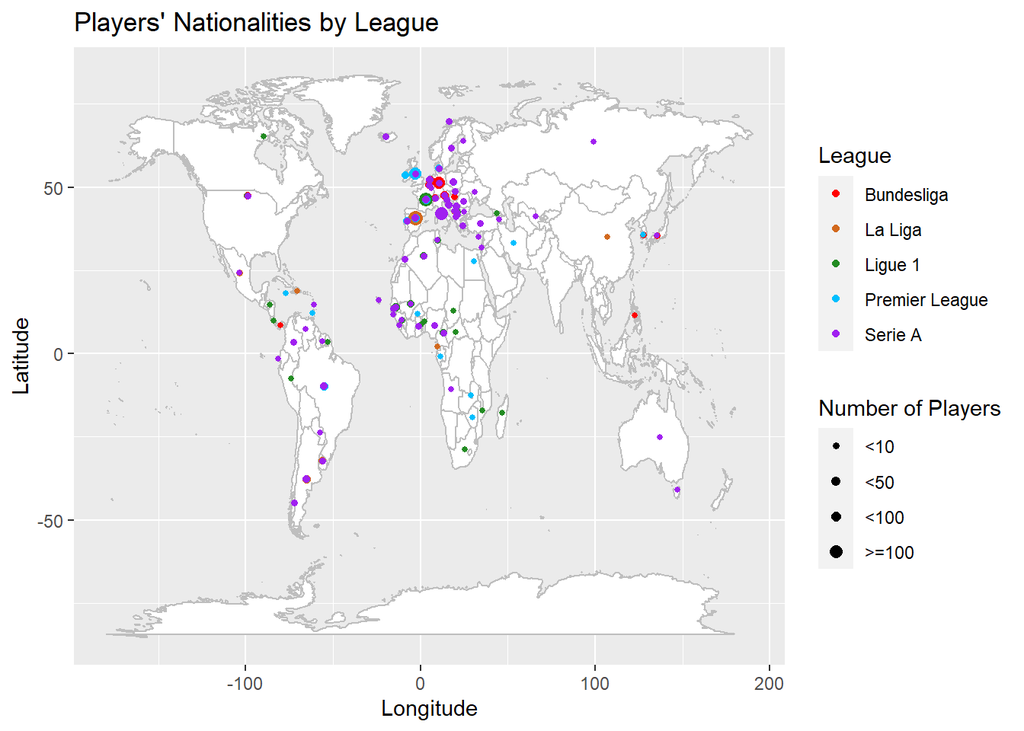

### Graph 1.1b: Europe Map of Players Nationalities, Colored by League and Sized by Aggregate Number of Players

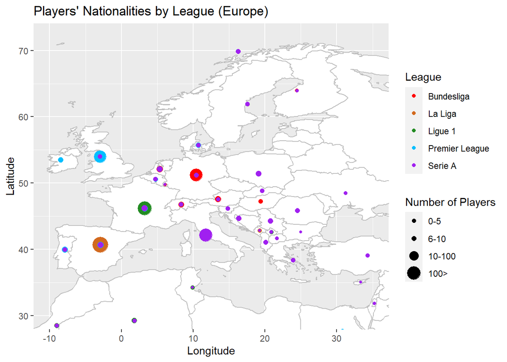

Narrowing down the map to countries in Europe, we can get a better idea about the number of players here than from the world map. It is apparent that La Liga players tend to primarily have a Spanish nationality, Ligue 1 players tend to primarily have a french Nationality, Premier League players tend to primarily have an English Nationality, and Bundesliga players tend to primarily have a German, Austrian, or Hungarian nationality. More notably, we see that while the majority of European Serie A players have an Italian nationality, the distribution is spread out across many European countries.

### Graph 1.2: Mosaic Plot of Player Position, Seperated by Continent of Player Nationality

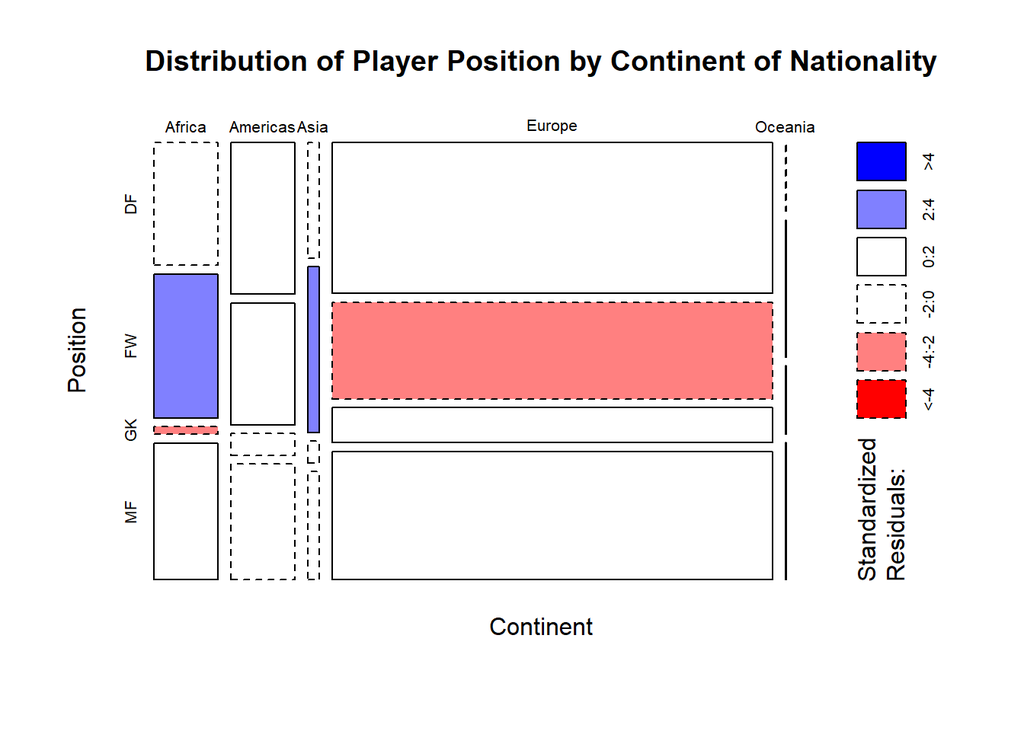

The above mosaic plot represents the distribution of player position across five continents, with Antarctica excluded and North and South America grouped into one continent. The proportions of defensive players and midfielders do not seem to be significantly different across the five continents, however differences emerge when we inspect the forward and goalkeeper positions. Most notably, players with African and Asian nationalities are over represented in the proportion of forwards and players with European nationalities are underrepresented. In the same way, players with African nationalities are underrepresented in the proportion of goalkeepers. One potential reason these differences may occur is due to differences in athleticism, genetic build, and training across different continents.

# Question 2: Do any trends of higher passing performance emerge within a specific position and league?

### Graph 2.1: Grouped Boxplot of Passing Accuracy vs. Player Position, Seperated by Soccer League

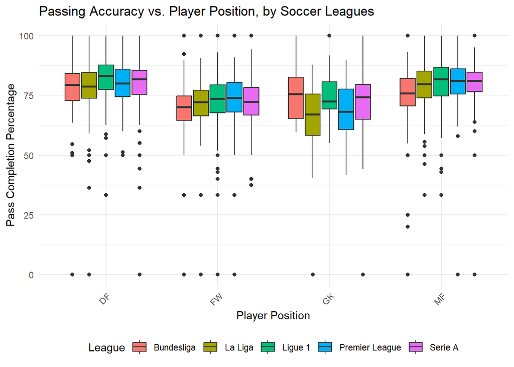

The box plot displays the distribution of passing completion percentages (`PasTotCmp%`) across different player positions, with the data color-coded by the league to show variations between leagues. The plot shows how passing completion percentages seems the highest for defenders, whereas forwards seem to have lower passing completion percentages. This might be because of defenders often engage in more controlled passes, while forwards may attempt riskier passes for goal-scoring opportunities.

The boxplots for different positions tend to overlap. Also, there does not seem to be a significant difference between the leagues for the passing accuracy by position, as all boxplots overlap for a given position. This plot seems to be relatively informative as we are easily able to compare the range of differences in passing accuracy by position and league that can help answer the question; however, there are some limitations. There appears to be many outliers, especially with lower passing percentages, for all positions other than goal keeper.

```
##                       Df Sum Sq Mean Sq F value   Pr(>F)
## Pos_simplified         3  41498   13833  94.623  < 2e-16 ***
## Comp                   4   6916    1729  11.827 1.57e-09 ***
## Pos_simplified:Comp   12   4830     403   2.754 0.000999 ***
## Residuals           2901 424093     146
## ---
## Signif. codes:  0 '***' 0.001 '**' 0.01 '*' 0.05 '.' 0.1 ' ' 1
```

After checking the Q-Q plot and residuals vs. fitted plot, the data seem to reasonably meet the assumptions for an ANOVA test. The ANOVA results above indicate significant differences in passing accuracy among different player positions (`Pos_simplified`), as indicated by the F-statistic of 94.623 (p-value < 2e-16), at the standard alpha level of 0.05. The factor `Comp` (representing soccer leagues) also significantly influences passing accuracy, with an F-statistic of 11.827 (p-value 1.57e-09), suggesting variations in passing performance across leagues. Furthermore, there is a significant interaction effect between player position and league (`Pos_simplified:Comp`), denoted by an F-statistic of 2.754 (p-value 0.000999), indicating that the impact of player position on passing accuracy differs across leagues. In summary, the findings suggest that both player position and league affiliation significantly contribute to differences in passing accuracy, and the interaction between these factors should be considered for a comprehensive understanding of the variations.

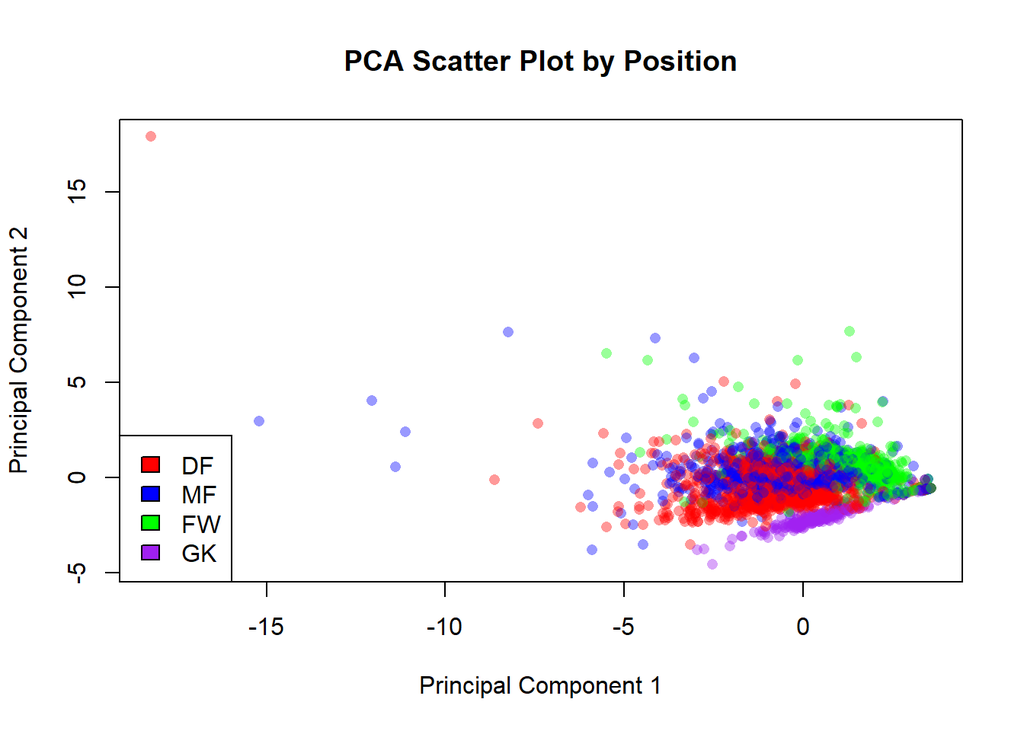

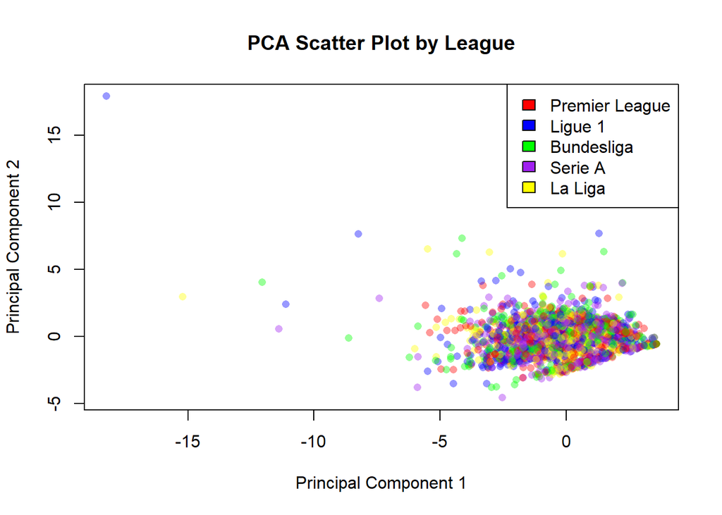

Using 7 passing variables- `PasTotCmp`, `PasTotDist`, `PasTotPrgDist`, `PasAss`, `PasProg`, `PasInt`, and `PasBlocks`- PCA projected the data into the lower-dimensional space defined by the first two principal components. There appears to be some grouping by player positions, suggesting that the principal components may capture patterns related to passing performance across different positions. However, there appears to limited distinction by league in the projection, suggesting that the variability explained may not strongly differentiate passing styles between the considered leagues.

```
## Importance of components:
##                           PC1    PC2    PC3     PC4     PC5    PC6     PC7
## Standard deviation     1.7327 1.2618 0.9368 0.82631 0.69654 0.5748 0.17217
## Proportion of Variance 0.4289 0.2274 0.1254 0.09754 0.06931 0.0472 0.00423
## Cumulative Proportion  0.4289 0.6563 0.7817 0.87926 0.94857 0.9958 1.00000
```

As shown above, the first two principle components explain 65.63% of the variability in the data. This indicates majority of the original information is captured in these two components, suggesting an effective reduction in dimensionality while retaining a considerable amount of the variability present in the seven passing variables.

# Question 3: What defensive factors are predictors of whether a player is able to make a goal, and does this potential relationship vary by position?

### Graph 3.1: Density Plot of Average Shot Distance Taken by Players Across Different Positions

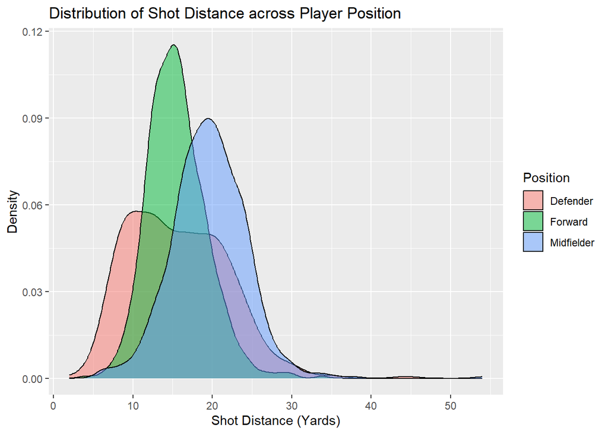

The above graph plots the density curves of the average distance players shot from, grouped into their respective positions. At a high level, we can see that players tend to be in the same ballpark in terms of shot distance regardless of player position. There are three main peaks around 10-20 yards. It may seem intuitive to believe that the goal accuracy would increase the closer one gets to the goal, so the fact that there is no concentration of shots right near the goal seems surprising. However, opponent defense may prevent a player from getting as close to the goal as they want or they may strategically choose to shoot from further, so the existence of large peaks further away is not too surprising. What is curious however,is the distribution of defender shot distance. Generally, we expect these players to shoot less often than their counterparts, however it appears that the curve is more spread out and even peaks slightly earlier than forwards. This indicate that they take shots from varying distances, whereas midfielders have high density of shots in the same bandwidth.

### Graph 3.2 : Grouped Bar Graph of Total Touches and Total Tackles Across Player Position and Zone of Field

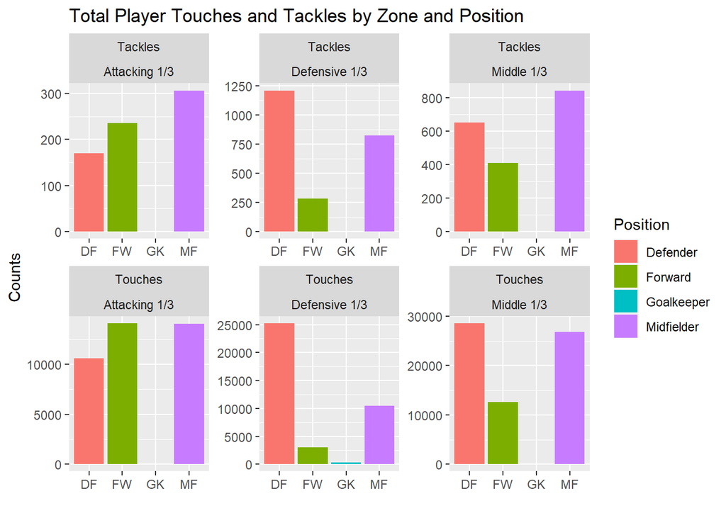

### Graph 3.3: Shot Distance vs. Number of Goals by Player Position

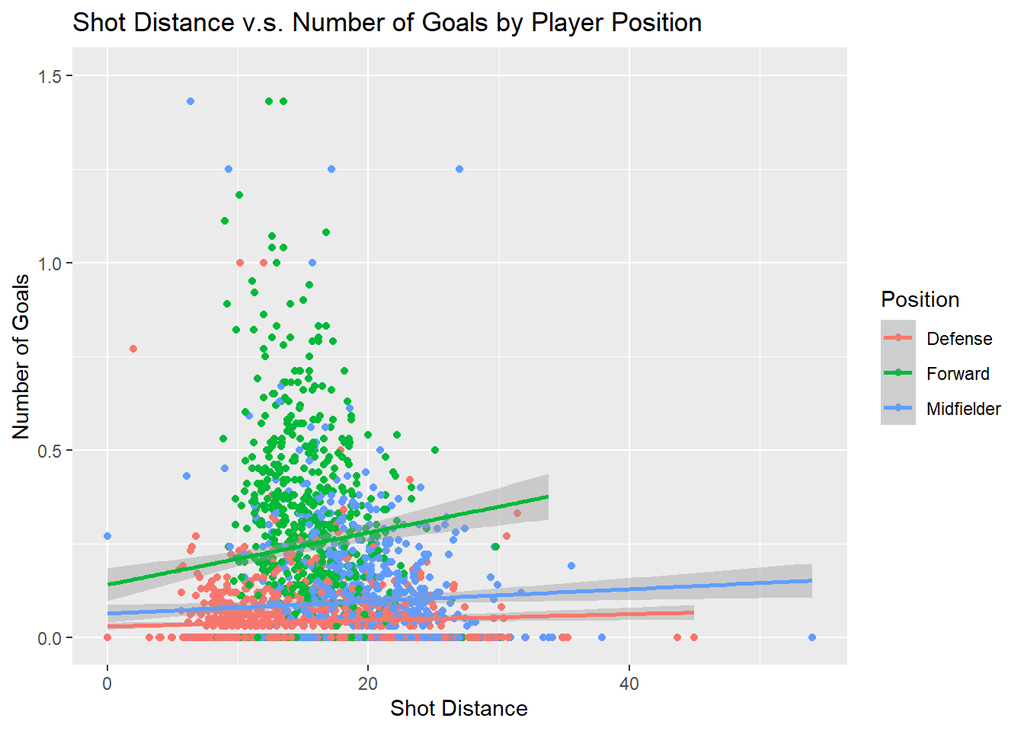

We can observe that there is a positive linear association between the number of goals scored and the distances that the shots were taken from for players in the forward position. The regression lines for each player position have differing slopes, suggesting that there is an interaction between shot distance and player position.

We can conduct a partial F-test to determine which defensive metrics are significant predictors of the number of goals a player can make. We will use the shot distance, position, number of interception, number of tackles, and number of fouls drawn variables as predictors of goals in our full model. We can test this full model against a reduced model which only includes the number of fouls and intercepts using the null hypothesis that the full model is correct and the alternative hypothesis that the reduced model is correct. The test will use a significance level of alpha = 0.05. If we find that the full model is correct, then we can conclude that shot distance, player position and the number of tackles are significant predictors of the number of goals.

```
## Analysis of Variance Table
##
## Model 1: Goals ~ Int + Fls
## Model 2: Goals ~ ShoDist * Pos_simplified + Int + Tkl + Fls
##   Res.Df    RSS Df Sum of Sq      F    Pr(>F)
## 1   2701 150.56
## 2   2695 132.63  6    17.933 60.732 < 2.2e-16 ***
## ---
## Signif. codes:  0 '***' 0.001 '**' 0.01 '*' 0.05 '.' 0.1 ' ' 1
```

Now that we have determined the significant predictors, we can conduct individual $\textit{t}$-tests, with 2695 degrees of freedom, on each $\hat{\beta_i}$ in our model to determine the nature of this association. We will test the null hypothesis that $\hat{\beta_i} = 0$ against the alternative that $\hat{\beta_i} \neq 0$, for a significance level of alpha = 0.05.

```
##
## Call:
## lm(formula = Goals ~ ShoDist * Pos_simplified + Int + Tkl + Fls,
##     data = noGoalie)
##
## Residuals:
##     Min      1Q  Median      3Q     Max
## -0.3680 -0.0849 -0.0347  0.0412  4.7572
##
## Coefficients:
##                            Estimate Std. Error t value Pr(>|t|)
## (Intercept)               0.0519446  0.0162431   3.198   0.0014 **
## ShoDist                   0.0009145  0.0008670   1.055   0.2916
## Pos_simplifiedFW          0.1494937  0.0256989   5.817 6.69e-09 ***
## Pos_simplifiedMF          0.0329268  0.0228894   1.439   0.1504
## Int                      -0.0071958  0.0038362  -1.876   0.0608 .
## Tkl                      -0.0078002  0.0032996  -2.364   0.0181 *
## Fls                       0.0043884  0.0031099   1.411   0.1583
## ShoDist:Pos_simplifiedFW  0.0039499  0.0016270   2.428   0.0153 *
## ShoDist:Pos_simplifiedMF  0.0007627  0.0012928   0.590   0.5553
## ---
## Signif. codes:  0 '***' 0.001 '**' 0.01 '*' 0.05 '.' 0.1 ' ' 1
##
## Residual standard error: 0.2218 on 2695 degrees of freedom
## Multiple R-squared:  0.1528, Adjusted R-squared:  0.1503
## F-statistic: 60.77 on 8 and 2695 DF,  p-value: < 2.2e-16
```

# Conclusion and Main Takeaways

The analysis revealed that the most common geographical areas represented in the UEFA’s European Leagues are Europe and Africa, with forwards tending to be over-represented in the latter and underrepresented in the former. Additionally, goalkeepers from Africa were underrepresented. We found that defenders tended to have a higher passing performance than other positions. Additionally, the position, league, and interaction between position and league of a player are all significant predictors of passing completion percentage, `PasTotCmp%`. PCA showed trends of within-group similarity for positions when considering various passing metrics, but there did not seem to be any trends for leagues. Finally, we found that player position, shooting distance, and the number of tackles are significant predictors of the number of goals a player will make in one game. In particular, shooting distance is positively and linearly associated with number of goals scored for forward players.

# Future Work

Potential areas to explore in the future include:

1. How team tactics influence individual passing performance and whether certain approaches enhance passing capabilities of players in specific positions.

Understanding how team tactics impact individual passing and identifying strategies to improve passing for specific positions can optimize performance, and additional variables not provided in this dataset regarding team dynamics might be useful along with `PasTotCmp%` and `PasProg`.

2. How player fatigue affects performance.

Exploring how player fatigue, measured by minutes played (`Min`), affects performance provides insights for injury prevention and player management.

3. Which teams have the most effective set-piece strategies.

Investigating which teams excel in set-piece strategies using variables like corner kicks (`CK`) and completed dead-ball passes leading to a goal (`GcaPassDead`) can guide match strategies.

# Sources

- [Kaggle](https://www.kaggle.com/datasets/vivovinco/20212022-football-player-stats)